# 20172_M2.855_PEC3-Enunciado_solucion

[figure not shown]

M2.855 · Modelos avanzados de minería de datos · PEC3

2017-2 · Máster universitario en Ciencia de datos (Data science)

Estudios de Informática, Multimedia y Telecomunicación

# PEC 3: Métodos supervisados

En esta práctica veremos diferentes métodos supervisados aplicados sobre el conjunto de datos [EMNIST](https://www.nist.gov/itl/iad/image-group/emnist-dataset) y posteriormente aplicaremos un algoritmo típicamente utilizado en problemas supervisados como son las redes neuronales en un problema con datos no etiquetados.

0. Carga de datos
1. $k$ vecinos más cercanos
2. Support vector machines
3. Redes neuronales
4. Aprendizaje no supervisado con redes neuronales

**Importante: Cada uno de los ejercicios puede suponer varios minutos de ejecución, por lo que la entrega debe hacerse en formato notebook y en formato html donde se vea el código y los resultados y comentarios de cada ejercicio. Para exportar el notebook a html puede hacerse desde el menú File $\to$ Download as $\to$ HTML.**

## 0. Carga de datos

El conjunto de datos EMNIST consiste en varios subconjuntos de datos con carácteres y dígitos escritos a mano. Para esta práctica utilizaremos únicamente un subconjunto de 5.000 imágenes que consiste en 1.000 imágenes de 5 clases diferentes ("A", "B", "C", "D" y "E").

Las imágenes tienen una resolución de 28x28 píxeles en escala de grises, por lo que se pueden representar utilizando un vector de 784 posiciones.

El siguiente código cargará las 5.000 imágenes en la variable *images* y las correspondientes etiquetas (en forma numérica) en la variable *labels*. Podemos comprobar que la carga ha sido correcta obteniendo las dimensiones de estas dos variables.

```python
import pickle
import numpy as np

with open("data.pickle", "rb") as f:
    data = pickle.load(f)

images = data["images"]
labels = data["labels"]
n_classes = 5
labels_text = ["A", "B", "C", "D", "E"]

print("Dimensiones del vector de imágenes: {}".format(images.shape))
print("Dimensiones del vector de etiquetas: {}".format(labels.shape))
```

```
Dimensiones del vector de imágenes: (5000, 784)
Dimensiones del vector de etiquetas: (5000,)
```

Con el siguiente código podemos ver un ejemplo de imagen de cada una de las clases. Para ello reajustamos el vector de 784 dimensiones que representa cada imagen en una matriz de tamaño 28x28 y la transponemos para mostrarla:

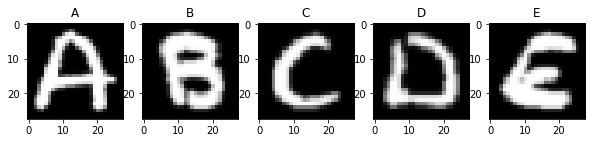

```python
import matplotlib.pyplot as plt
%matplotlib inline

fig, ax = plt.subplots(1, n_classes, figsize=(10,10))

idxs = [np.where(labels == i)[0] for i in range(n_classes)]

for i in range(n_classes):
    k = np.random.choice(idxs[i])
    ax[i].imshow(images[k].reshape(28, 28).transpose(), cmap="gray")
    ax[i].set_title("{}".format(labels_text[i]))
```

De las 5.000 imágenes distintas utilizaremos 4.000 imágenes para entrenar los diferentes modelos y 1.000 imágenes para validar los resultados. Con el siguiente código separamos los datos que hemos cargado anteriormente en dos conjuntos, train y test, de forma estratificada, es decir, en cada uno de los conjuntos las clases aparecen en la misma proporción que en el conjunto original.

En lugar de trabajar directamente con un vector de 784 dimensiones para cada imagen aplicaremos primero el algoritmo PCA para reducir la dimensión de los ejemplos a 100. El proceso de entrenamiento de PCA lo hacemos con las imágenes de train y luego lo aplicamos también sobre las imágenes de test, de forma que no utilizamos ninguna información de las imágenes en el conjunto de test para entrenar los modelos.

```python
from sklearn.model_selection import train_test_split
from sklearn.decomposition import PCA

X_train, X_test, y_train, y_test = train_test_split(images, labels, test_size=0.2, random_state=2017, stratify=labels)

pca = PCA(n_components=100, random_state=2017)
pca_fit = pca.fit(X_train)
X_train_pca = pca_fit.transform(X_train)
X_test_pca = pca_fit.transform(X_test)

def proporcion_etiquetas(y):
    _, count = np.unique(y, return_counts=True)
    return np.true_divide(count, y.shape[0])


print("Número de imágenes para entrenar: {}".format(X_train_pca.shape[0]))
print("Número de imágenes para test: {}".format(X_test_pca.shape[0]))

print("Proporción de las etiquetas en el conjunto original: {}".format(proporcion_etiquetas(labels)))
print("Proporción de las etiquetas en el conjunto de entrenamiento: {}".format(proporcion_etiquetas(y_train)))
print("Proporción de las etiquetas en el conjunto de test: {}".format(proporcion_etiquetas(y_test)))
```

```
Número de imágenes para entrenar: 4000
Número de imágenes para test: 1000
Proporción de las etiquetas en el conjunto original: [ 0.2  0.2  0.2  0.2  0.2]
Proporción de las etiquetas en el conjunto de entrenamiento: [ 0.2  0.2  0.2  0.2  0.2]
Proporción de las etiquetas en el conjunto de test: [ 0.2  0.2  0.2  0.2  0.2]
```

## 1. $k$ vecinos más cercanos (2 puntos)

El primer algoritmo que utilizaremos para clasificar las imágenes de las letras es el $k$-nn. En este ejercicio ajustaremos dos hiperparámetros del algoritmo:

- $k$: el número de vecinos que se consideran para clasificar un nuevo ejemplo. Probaremos con todos los valores entre 1 y 10.
- pesos: importancia que se da a cada uno de los vecinos considerados. En este caso probaremos dos opciones: pesos uniformes, donde todos los vecinos se consideran igual; y pesos según distancia, donde los vecinos más cercanos tienen más peso en la clasificación que los vecinos más lejanos.

Para decidir cuáles son los hiperparámetros óptimos utilizaremos una búsqueda de rejilla (grid search), es decir, entrenaremos un modelo para cada combinación de hiperparámetros posible y la evaluaremos utilizando validación cruzada (cross validation) con 4 particiones estratificadas. Posteriormente escogeremos la combinación de hiperparámetros que mejor resultados haya dado.

**Implementación:** cálculo del valor óptimo de los hiperparámetros $k$ y pesos. Podéis utilizar los módulos GridSearchCV y KNeighborsClassifier de sklearn.

**Solución:**

```python
from sklearn.model_selection import GridSearchCV
from sklearn.neighbors import KNeighborsClassifier
from time import time

clf = KNeighborsClassifier()

param_grid = {"n_neighbors": range(1, 11), "weights": ["uniform", "distance"]}

grid_search = GridSearchCV(clf, param_grid=param_grid, cv=4)

start = time()
grid_search.fit(X_train_pca, y_train)
end = time()

print("La búsqueda llevó {} segundos".format(end - start))

means = grid_search.cv_results_["mean_test_score"]
stds = grid_search.cv_results_["std_test_score"]
params = grid_search.cv_results_['params']
ranks = grid_search.cv_results_['rank_test_score']

for rank, mean, std, pms in zip(ranks, means, stds, params):
    print("{}) Precisión media: {:.2f} +/- {:.2f} con parámetros {}".format(rank, mean*100, std*100, pms))
```

```
La búsqueda llevó 198.22685599327087 segundos
6) Precisión media: 94.73 +/- 0.35 con parámetros {'weights': 'uniform', 'n_neighbors': 1}
6) Precisión media: 94.73 +/- 0.35 con parámetros {'weights': 'distance', 'n_neighbors': 1}
20) Precisión media: 93.27 +/- 0.51 con parámetros {'weights': 'uniform', 'n_neighbors': 2}
6) Precisión media: 94.73 +/- 0.35 con parámetros {'weights': 'distance', 'n_neighbors': 2}
3) Precisión media: 94.83 +/- 0.32 con parámetros {'weights': 'uniform', 'n_neighbors': 3}
2) Precisión media: 95.00 +/- 0.22 con parámetros {'weights': 'distance', 'n_neighbors': 3}
14) Precisión media: 94.35 +/- 0.57 con parámetros {'weights': 'uniform', 'n_neighbors': 4}
1) Precisión media: 95.17 +/- 0.25 con parámetros {'weights': 'distance', 'n_neighbors': 4}
11) Precisión media: 94.60 +/- 0.82 con parámetros {'weights': 'uniform', 'n_neighbors': 5}
11) Precisión media: 94.60 +/- 0.74 con parámetros {'weights': 'distance', 'n_neighbors': 5}
19) Precisión media: 94.12 +/- 0.64 con parámetros {'weights': 'uniform', 'n_neighbors': 6}
4) Precisión media: 94.80 +/- 0.46 con parámetros {'weights': 'distance', 'n_neighbors': 6}
16) Precisión media: 94.25 +/- 0.51 con parámetros {'weights': 'uniform', 'n_neighbors': 7}
10) Precisión media: 94.65 +/- 0.57 con parámetros {'weights': 'distance', 'n_neighbors': 7}
16) Precisión media: 94.25 +/- 0.50 con parámetros {'weights': 'uniform', 'n_neighbors': 8}
9) Precisión media: 94.70 +/- 0.62 con parámetros {'weights': 'distance', 'n_neighbors': 8}
14) Precisión media: 94.35 +/- 0.46 con parámetros {'weights': 'uniform', 'n_neighbors': 9}
13) Precisión media: 94.47 +/- 0.33 con parámetros {'weights': 'distance', 'n_neighbors': 9}
18) Precisión media: 94.17 +/- 0.45 con parámetros {'weights': 'uniform', 'n_neighbors': 10}
5) Precisión media: 94.75 +/- 0.69 con parámetros {'weights': 'distance', 'n_neighbors': 10}
```

**Análisis:** ¿Qué parámetros han dado mejores resultados? ¿Qué variación hay entre las diferentes combinaciones de parámetros? ¿Es significativa la variación entre las diferentes combinaciones? ¿Hay algún parámetro que influya más que el otro? ¿Era de esperar?

**Implementación:** entrenar un modelo $k$-nn con los valores de los hiperparámetros óptimos utilizando todo el conjunto *X_train_pca* y mostrar la precisión de la predicción del modelo en el conjunto *X_test_pca*.

**Solución:**

```python
print("Valor óptimo para k: {}".format(grid_search.best_params_["n_neighbors"]))
print("Valor óptimo para weights: {}".format(grid_search.best_params_["weights"]))

clf = KNeighborsClassifier(n_neighbors=grid_search.best_params_["n_neighbors"], weights=grid_search.best_params_["weights"])
clf.fit(X_train_pca, y_train)

preds = clf.predict(X_test_pca)

accuracy = np.true_divide(np.sum(preds == y_test), preds.shape[0])*100
print("Precisión en el conjunto de test: {:.2f}%".format(accuracy))
```

```
Valor óptimo para k: 4
Valor óptimo para weights: distance
Precisión en el conjunto de test: 94.40%
```

**Implementación:** mostrar la matriz de confusión del modelo y algunas imágenes que el modelo haya clasificado incorrectamente junto con la etiqueta asignada por el modelo y la etiqueta original.

**Solución:**

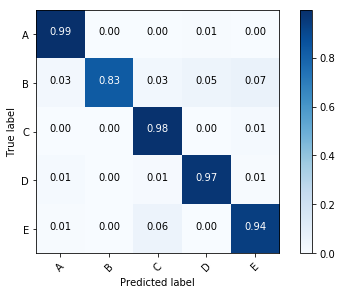

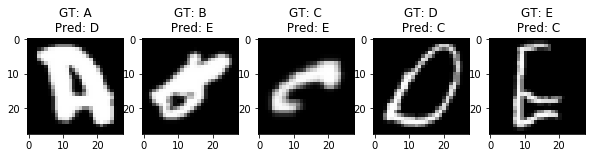

```python
import itertools
from sklearn.metrics import confusion_matrix

cnf_matrix = confusion_matrix(y_test, preds)

def plot_confusion_matrix(cm, classes):
    cm = cm.astype('float') / cm.sum(axis=1)[:, np.newaxis]

    cmap=plt.cm.Blues

    plt.imshow(cm, interpolation='nearest', cmap=cmap)
    plt.colorbar()
    tick_marks = np.arange(len(classes))
    plt.xticks(tick_marks, classes, rotation=45)
    plt.yticks(tick_marks, classes)

    thresh = cm.max() / 2.
    for i, j in itertools.product(range(cm.shape[0]), range(cm.shape[1])):
        plt.text(j, i, format(cm[i, j], ".2f"),
                 horizontalalignment="center",
                 color="white" if cm[i, j] > thresh else "black")

    plt.tight_layout()
    plt.ylabel('True label')
    plt.xlabel('Predicted label')

plot_confusion_matrix(cnf_matrix, classes=labels_text)

fig, ax = plt.subplots(1, n_classes, figsize=(10,10))

idxs = [np.where((y_test == i) & (preds != i))[0] for i in range(n_classes)]

for i in range(n_classes):
    k = np.random.choice(idxs[i])
    ax[i].imshow(X_test[k].reshape(28, 28).transpose(), cmap="gray")
    ax[i].set_title("GT: {}\n Pred: {}".format(labels_text[y_test[k]], labels_text[preds[k]]))
```

**Análisis:** ¿Cómo son los errores? ¿Parecen razonables?

**Solución:**  
- Es interesante notar que cuando el modelo predice "B" casi nunca se equivoca.  
- La confusión más grande aparece entre "C" y "E" además de entre "E" y "B".  
- Viendo algunos ejemplos parece razonable que el modelo confunda algunas imágenes que están muy deformadas. Otras imágenes en las que se equivoca también se podría justificar porque la forma de las letras se parecen en algunos casos concretos.

## 2. Support Vector Machines (2 puntos)

En este segundo ejercicio clasificaremos las imágenes de las letras utilizando el algoritmo SVM con el kernel radial. En este caso, en lugar de utilizar una búsqueda de rejilla para ajustar los hiperparámetros del algoritmo utilizaremos una búsqueda aleatoria, es decir, probaremos combinaciones de parámetros al azar. Los hiperparámetros a optimizar son:

- C: el valor de penalización de los errores en la clasificación. Marca el compromiso entre obtener el hiperplano con el mayor margen posible y clasificar el máximo número de ejemplos correctamente. Probaremos valores aleatorios distribuidos uniformemente entre 1 y 500.
- gamma: coeficiente que multiplica la distancia entre dos puntos en el kernel radial. Probaremos valores aleatorios distribuidos uniformemente entre $10^{-9}$ y $10^{-5}$.

Igual que en el caso anterior, para validar el rendimiento del algoritmo con cada combinación de hiperparámetros utilizaremos validación cruzada (cross-validation) con 4 particiones estratificadas.

**Implementación:** cálculo del valor óptimo de los hiperparámetros C y gamma utilizando 10 combinaciones de parámetros elegidas al azar. Podéis utilizar los módulos RandomizedSearchCV y svm de sklearn, así como el módulo uniform de scipy.

**Solución:**

```python
from sklearn.model_selection import RandomizedSearchCV
from sklearn import svm
from scipy.stats import uniform as sp_rand
from time import time

clf = svm.SVC()

param_dist = {"C": sp_rand(loc=1, scale=500), "gamma": sp_rand(loc=1e-9, scale=1e-5)}

n_iter_search = 10
random_search = RandomizedSearchCV(clf, param_distributions=param_dist, n_iter=n_iter_search, cv=4)

start = time()
random_search.fit(X_train_pca, y_train)
end = time()

print("La búsqueda llevó {} segundos".format(end - start))

means = random_search.cv_results_["mean_test_score"]
stds = random_search.cv_results_["std_test_score"]
params = random_search.cv_results_['params']
ranks = random_search.cv_results_['rank_test_score']

for rank, mean, std, pms in zip(ranks, means, stds, params):
    print("{}) Precisión media: {:.2f} +/- {:.2f} con parámetros {}".format(rank, mean*100, std*100, pms))
```

```
La búsqueda llevó 259.9114935398102 segundos
7) Precisión media: 46.30 +/- 1.70 con parámetros {'gamma': 4.6175269259661253e-06, 'C': 1.3295740780045464}
5) Precisión media: 52.20 +/- 1.67 con parámetros {'gamma': 3.8269761312803746e-06, 'C': 156.14467484627508}
6) Precisión media: 47.10 +/- 1.77 con parámetros {'gamma': 4.5031452177587274e-06, 'C': 204.53550978579037}
8) Precisión media: 35.60 +/- 1.41 con parámetros {'gamma': 7.0288690755272156e-06, 'C': 326.39597796989511}
10) Precisión media: 31.27 +/- 2.06 con parámetros {'gamma': 8.4241865594969794e-06, 'C': 381.65147677278088}
3) Precisión media: 70.40 +/- 1.15 con parámetros {'gamma': 2.1808359847300035e-06, 'C': 328.57534820313828}
4) Precisión media: 60.32 +/- 1.79 con parámetros {'gamma': 3.0258554630232185e-06, 'C': 308.70197718973685}
1) Precisión media: 96.10 +/- 0.55 con parámetros {'gamma': 7.5570822479885128e-07, 'C': 260.33142048359758}
9) Precisión media: 33.77 +/- 1.64 con parámetros {'gamma': 7.5606582515779346e-06, 'C': 471.98760827893443}
2) Precisión media: 87.90 +/- 0.49 con parámetros {'gamma': 1.3194179766321604e-06, 'C': 64.170181522916323}
```

**Análisis:** ¿Qué parámetros han dado mejores resultados? ¿Qué variación hay entre las diferentes combinaciones de parámetros? ¿Es significativa la variación entre las diferentes combinaciones? ¿Hay algún parámetro que influya más que el otro? ¿Era de esperar?

**Solución:**  
- La mejor combinación se da con C = 260 y gamma = $10^{-7}$.  
- Las diferencias en la precisión son muy grandes, y teniendo en cuenta la desviación estandard es claro que hay combinaciones claramente mejores que otras.  
- Las mejores soluciones se dan con gamma del orden de $10^{-7}$ y se va perdiendo precisión a medida que aumenta el valor del parámetro gamma. Se puede ver que en las mejores soluciones el valor de C es bastante variable, por lo que podemos deducir que el parámetro gamma tiene mucho más peso, lo cual es típico al utilizar el kernel radial.

**Implementación:** entrenar un modelo SVM con los valores de los hiperparámetros óptimos utilizando todo el conjunto *X_train_pca* y mostrar la precisión de la predicción del modelo en el conjunto *X_test_pca*.

**Solución:**

```python
print("Valor óptimo para C: {}".format(random_search.best_params_["C"]))
print("Valor óptimo para gamma: {}".format(random_search.best_params_["gamma"]))

clf = svm.SVC(C=random_search.best_params_["C"], gamma=random_search.best_params_["gamma"])
clf.fit(X_train_pca, y_train)

preds = clf.predict(X_test_pca)

accuracy = np.true_divide(np.sum(preds == y_test), preds.shape[0])*100
print("Precisión en el conjunto de test: {:.2f}%".format(accuracy))
```

```
Valor óptimo para C: 260.3314204835976
Valor óptimo para gamma: 7.557082247988513e-07
Precisión en el conjunto de test: 96.80%
```

**Implementación:** mostrar la matriz de confusión del modelo y algunas imágenes que el modelo haya clasificado incorrectamente junto con la etiqueta asignada por el modelo y la etiqueta original.

**Solución:**

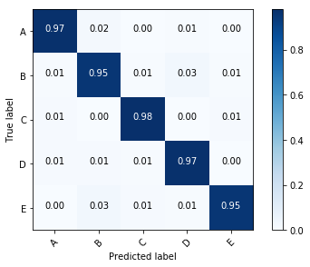

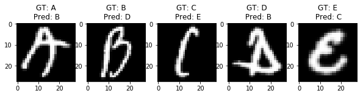

```python
cnf_matrix = confusion_matrix(y_test, preds)

plot_confusion_matrix(cnf_matrix, classes=labels_text)

fig, ax = plt.subplots(1, n_classes, figsize=(10,10))

idxs = [np.where((y_test == i) & (preds != i))[0] for i in range(n_classes)]

for i in range(n_classes):
    k = np.random.choice(idxs[i])
    ax[i].imshow(X_test[k].reshape(28, 28).transpose(), cmap="gray")
    ax[i].set_title("GT: {}\n Pred: {}".format(labels_text[y_test[k]], labels_text[preds[k]]))
```

**Análisis:** ¿Cómo son los errores? ¿Parecen razonables?

**Solución:**  
- Este modelo parece clasificar ligeramente mejor las imágenes de la letra "B" que el modelo anterior, pero un poco peor las imágenes de la letra "A".  
- La mayor confusión para este modelo está entre "B" y "E", junto con la confusión entre "D" y "B".  
- La letra con la que el modelo está más seguro al predecir es la letra "E".  
- Viendo algunos ejemplos de errores estos parecen bastante razonables.

## 3. Redes neuronales (3 puntos)

Como tercer ejercicio utilizaremos una red neuronal para clasificar las imágenes de las letras. Utilizaremos también ahora una búsqueda aleatoria para ajustar los hiperparámetros de la red neuronal. En particular, utilizaremos una red monocapa con 5 salidas (una para cada clase del conjunto de datos) entrenada con el método de retropropagación y el optimizador SGD. Las neuronas de la capa ocula tendrán como activación la función sigmoide. Los hiperparámetros a ajustar en este caso son los siguientes:

- Número de neuronas de la capa oculta: probaremos valores entre 20 y 1000.
- Número de épocas de entrenamiento: probaremos valores entre 10 y 150.
- Velocidad de aprendizaje (learning rate): probaremos valores entre 0.0001 y 0.2.

El procedimiento para validar el rendimiento del modelo para cada combinación de parámetros será el mismo que en los casos anteriores: validación cruzada con 4 particiones generadas de forma estratificada.

**Implementación:** cálculo del valor óptimo del número de neuronas de la capa oculta, el número de épocas de entrenamiento y la velocidad de aprendizaje utilizando 10 combinaciones de parámetros elegidas al azar. Podéis utilizar los módulos Sequential, Dense y SGD de keras, además de uniform y randint de scipy y StratifiedKFold de sklearn.

**Solución:**

```python
import keras
from keras.models import Sequential
from keras.layers import Dense
from keras.optimizers import SGD
from sklearn.model_selection import StratifiedKFold
from scipy.stats import uniform as sp_rand
from scipy.stats import randint
from time import time

kf = StratifiedKFold(n_splits=4)

n_iter_search = 10
params = np.zeros((n_iter_search, 3))

n_neurons_dist = randint(low=20, high=1000)
n_epochs_dist = randint(low=10, high=150)
lr_dist = sp_rand(loc=0.0001, scale=0.2)

best_it = -1
max_score = 0

start = time()
for i in range(n_iter_search):
    n_neurons = n_neurons_dist.rvs()
    n_epochs = n_epochs_dist.rvs()
    lr = lr_dist.rvs()

    params[i, 0] = n_neurons
    params[i, 1] = n_epochs
    params[i, 2] = lr

    print("Prueba {}".format(i))
    print("Número de neuronas: {}; Número de épocas: {}; Velocidad de aprendizaje: {}".format(n_neurons, n_epochs, lr))

    scores = np.zeros(4)
    j = 0
    for train_index, test_index in kf.split(X_train_pca, y_train):
        X_train_kf, X_test_kf = X_train_pca[train_index], X_train_pca[test_index]
        y_train_kf, y_test_kf = y_train[train_index], y_train[test_index]

        y_train_kf = keras.utils.to_categorical(y_train_kf, num_classes=n_classes)
        y_test_kf = keras.utils.to_categorical(y_test_kf, num_classes=n_classes)

        model = Sequential()
        model.add(Dense(n_neurons, input_shape=(100,), activation="sigmoid"))
        model.add(Dense(n_classes, activation='softmax'))

        model.compile(optimizer=SGD(lr=lr), loss='categorical_crossentropy', metrics=['accuracy'])

        model.fit(X_train_kf, y_train_kf, epochs=n_epochs, verbose=0)

        score = model.evaluate(X_test_kf, y_test_kf, verbose=0)
        scores[j] = score[1]
        j += 1

    score_mean = np.mean(scores)
    score_std = np.std(scores)
    print("Precisión media: {:.2f} +/- {:.2f}".format(score_mean*100, score_std*100))

    if (score_mean > max_score):
        max_score = score_mean
        best_it = i

end = time()

print("La búsqueda llevó {} segundos".format(end - start))
```

```
Prueba 0
Número de neuronas: 28; Número de épocas: 32; Velocidad de aprendizaje: 0.09504850179991949
Precisión media: 88.35 +/- 2.45
Prueba 1
Número de neuronas: 316; Número de épocas: 136; Velocidad de aprendizaje: 0.0382351904328215
Precisión media: 93.15 +/- 1.15
Prueba 2
Número de neuronas: 690; Número de épocas: 118; Velocidad de aprendizaje: 0.010792966196095988
Precisión media: 92.58 +/- 0.33
Prueba 3
Número de neuronas: 171; Número de épocas: 20; Velocidad de aprendizaje: 0.15642801100600423
Precisión media: 91.07 +/- 1.25
Prueba 4
Número de neuronas: 412; Número de épocas: 72; Velocidad de aprendizaje: 0.1344805965320678
Precisión media: 92.33 +/- 0.97
Prueba 5
Número de neuronas: 38; Número de épocas: 19; Velocidad de aprendizaje: 0.035333185792935574
Precisión media: 90.95 +/- 1.36
Prueba 6
Número de neuronas: 607; Número de épocas: 126; Velocidad de aprendizaje: 0.19464100076597973
Precisión media: 88.40 +/- 7.37
Prueba 7
Número de neuronas: 523; Número de épocas: 37; Velocidad de aprendizaje: 0.030616199203039297
Precisión media: 92.77 +/- 0.97
Prueba 8
Número de neuronas: 553; Número de épocas: 40; Velocidad de aprendizaje: 0.07096888505639032
Precisión media: 93.40 +/- 0.85
Prueba 9
Número de neuronas: 921; Número de épocas: 67; Velocidad de aprendizaje: 0.02067589653425709
Precisión media: 93.23 +/- 0.80
La búsqueda llevó 553.488269329071 segundos
```

**Análisis:** ¿Qué parámetros han dado mejores resultados? ¿Qué variación hay entre las diferentes combinaciones de parámetros? ¿Es significativa la variación entre las diferentes combinaciones? ¿Hay algún parámetro que influya más que los otros? ¿Era de esperar?

**Solución:**  
- La mayor precisión se obtiene con 553 neuronas en la capa oculta y entrenando 40 épocas con una velocidad de aprendizaje de 0.071.  
- En este caso podemos ver mayores desviaciones estandar en la media de precisión pero aún así los valores medios de precisión son bastante diferentes, por lo que todavía podemos afirmar que algunas soluciones son mejores que otras.  
- Con pocas pruebas y las desviaciones estandard altas es difícil extraer relaciones claras entre hiperparámetros, pero parece aflorar que, con una velocidad de aprendizaje pequeña, lo mejor es tener un número alto de neuronas en la capa intermedia y entrenar muchas épocas.

**Implementación:** entrenar una red neuronal con los valores de los hiperparámetros óptimos utilizando todo el conjunto *X_train_pca* y mostrar la precisión de la predicción del modelo en el conjunto *X_test_pca*.

**Solución:**

```python
print("Número de neuronas óptimo: {}".format(params[best_it, 0]))
print("Número de épocas óptimo: {}".format(params[best_it, 1]))
print("Velocidad de aprendizaje óptima: {}".format(params[best_it, 2]))

model = Sequential()
model.add(Dense(int(params[best_it, 0]), input_shape=(100,), activation="sigmoid"))
model.add(Dense(n_classes, activation='softmax'))

model.compile(optimizer=SGD(lr=params[best_it, 2]), loss='categorical_crossentropy', metrics=['accuracy'])

model.fit(X_train_pca, keras.utils.to_categorical(y_train, num_classes=n_classes), epochs=int(params[best_it, 1]), verbose=0)

preds = np.argmax(model.predict(X_test_pca, verbose=0), axis=1)

accuracy = np.true_divide(np.sum(preds == y_test), preds.shape[0])*100
print("Precisión en el conjunto de test: {:.2f}%".format(accuracy))
```

```
Número de neuronas óptimo: 553.0
Número de épocas óptimo: 40.0
Velocidad de aprendizaje óptima: 0.07096888505639032
Precisión en el conjunto de test: 93.60%
```

**Implementación:** mostrar la matriz de confusión del modelo y algunas imágenes que el modelo haya clasificado incorrectamente junto con la etiqueta asignada por el modelo y la etiqueta original.

**Solución:**

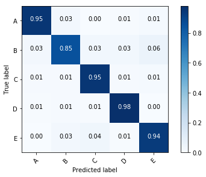

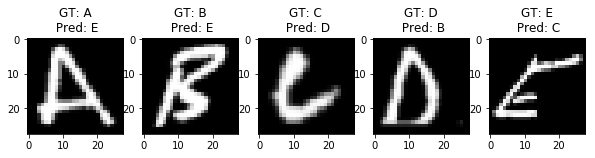

```python
cnf_matrix = confusion_matrix(y_test, preds)

plot_confusion_matrix(cnf_matrix, classes=labels_text)

fig, ax = plt.subplots(1, n_classes, figsize=(10,10))

idxs = [np.where((y_test == i) & (preds != i))[0] for i in range(n_classes)]

for i in range(n_classes):
    k = np.random.choice(idxs[i])
    ax[i].imshow(X_test[k].reshape(28, 28).transpose(), cmap="gray")
    ax[i].set_title("GT: {}\n Pred: {}".format(labels_text[y_test[k]], labels_text[preds[k]]))
```

**Análisis:** ¿Cómo son los errores? ¿Parecen razonables?

**Solución:**  
- Este modelo confunde muchas bastante la letra "B" con otras letras, en especial con la letra "E", lo cual parece razonable en general  
- La letra que mejor clasifica en este caso es la letra "D", qe las detecta de forma casi perfecta.  
- Viendo algunos ejemplos parece que los ejemplos donde se equivoca el modelo un humano los hubiera clasificado correctamente.

## 4. Aprendizaje no supervisado con redes neuronales (3 puntos)

Tras el resurgimiento de las redes neuronales se han producido múltiples avances en el área de aprendizaje no supervisado. Una de las aplicaciones principales en este sentido son los autoencoders. La intuición tras un autoencoder clásico es **aprender una representación más compacta de la entrada** tratando de reconstruirla en su salida.

Un autoencoder consiste en una red neuronal monocapa donde el número de neuronas en la salida coincide con el número de neuronas de entrada, mientras que la capa oculta dispone de menos neuronas. Tras entrenar una red de este tipo se puede utilizar la salida para, por ejemplo, [eliminar ruido](https://www.doc.ic.ac.uk/~js4416/163/website/autoencoders/denoising.html), pero su capa intermedia también atrae interés porque es una representación "compacta" de la entrada que ha aprendido a extraer su información esencial para maximizar el éxito en la reconstrucción.

[figure not shown]

Fig. 1. Esquema de autoencoder

[figure not shown]

Fig. 2. Ejemplo de autoencoder

Tal y como se puede observar en la figura 2, la capa o capas que llevan hasta la representación compacta se llaman *Encoder*, y la parte que va desde la representación compacta hasta la salida se denomina *Decoder*.

En este ejercicio utilizaremos un autoencoder con 2 neuronas en la capa intermedia para obtener una representación en dos dimensiones de las series temporales correspondientes al precio de diferentes criptomonedas. Esto nos permitirá mostrar la representación compacta de las criptomonedas en un plano y clusterizar visualmente aquellas criptomonedas que hayan tenido un comportamiento similar a lo largo del tiempo.

El siguiente código descarga la información de las criptomonedas. Concretamente, utilizamos la [*API* de cryptocompare](https://www.cryptocompare.com/api/) para descargar el precio de cierre de cada día durante el último año de 100 criptomonedas.

```python
import json
import requests

N_DAYS = 365
N_COINS = 100

# Get coin list.
response = requests.get('https://www.cryptocompare.com/api/data/coinlist/')
coins = [k for k, v in json.loads(response.text)['Data'].items() if int(v['SortOrder']) <= N_COINS]

# Get daily @ close for each coin.
series = {}
for coin in coins:
    try:
        response = requests.get('https://min-api.cryptocompare.com/data/histoday?fsym={}&tsym=USD&limit={}&e=CCCAGG'.format(coin, N_DAYS - 1))
        data = json.loads(response.text)['Data']
        if (len(data) == N_DAYS and all(t < 100000 for t in [d['close'] for d in data])):
            series[coin] = [x['close'] for x in data]
            print(coin, end=' ')
        else:
            print('*{}*'.format(coin), end=' ')
    except:
        print('*{}*'.format(coin), end=' ')
```

```
AXR CASH DGB XPD ARG CINNI CRACK DGC BUK XMY NXTI CHASH ENRG BET AC 2015 GIVE BLK CAP BEN CXC DASH CNL AUR SUP XRP BTCD ARI XVG CNC QTL DT AMC ACOIN XMR CRAIG CETI KOBO CACH COOL PRC CBX MOON BLU BTM ETH BTC ALF CAT1 BTS DMD CLOAK XDP BTE CCN CIN CLAM CAIX NXT RIC CMC DOGE *42* PPC *CRC** DEM ETC AE…
```

Con el siguiente código podemos ver la información descargada para cada moneda en un único gráfico.

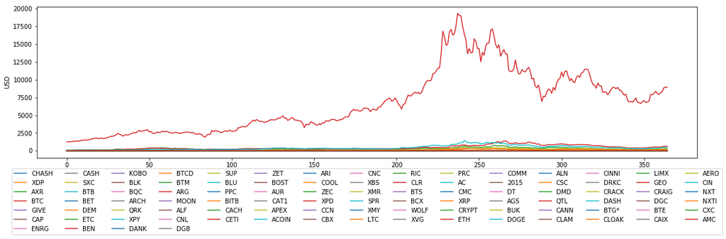

```python
fig, ax = plt.subplots(1, 1, figsize=(16, 4))
for k, v in series.items():
    ax.plot(range(len(v)), v, label=k)
    ax.set_ylabel('USD')
plt.legend(loc='upper center', bbox_to_anchor=(0.5, -0.05), fancybox=True, shadow=False, ncol=15)
plt.tight_layout()
```

En la gráfica anterior se observa como pocas monedas (como BTC, Bitcoin) tienen valores muy altos en USD (miles de dólares), pero la mayoría tienen poco valor (típicamente centavos). Para encontrar similitudes entre series con independencia de su escala (y para facilitar el entrenamiento del autoencoder) es buena idea normalizar las series.

Con el siguiente código primero normalizamos las series dividiendo cada valor por el máximo de la serie y volvemos a mostrar la gráfica.

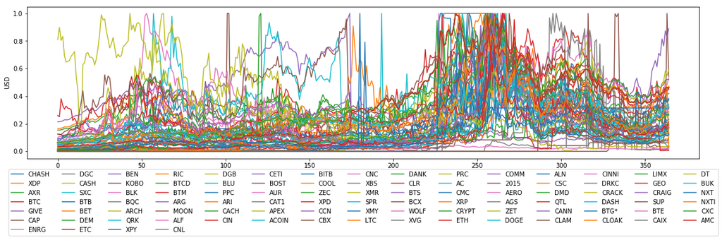

```python
series_norm = {k: np.array(v) / max(v) for k, v in series.items()}

fig, ax = plt.subplots(1, 1, figsize=(16, 4))
for k, v in series_norm.items():
    ax.plot(range(len(v)), v, label=k)
    ax.set_ylabel('USD')
plt.legend(loc='upper center', bbox_to_anchor=(0.5, -0.05), fancybox=True, shadow=False, ncol=15)
plt.tight_layout()
```

A continuación crearemos el autoencoder utilizando una capa de entrada con tantas neuronas como días tenemos de información, una capa intermedia con dos neuronas para facilitar la visualización de los datos comprimidos y una capa de salida con el mismo número de neuronas que la capa de entrada. Para este ejercicio utilizaremos neuronas con la tangente hiperbólica como función de activación.

**Implementación:** Construir y entrenar el autoencoder teniendo en cuenta que en el siguiente ejercicio necesitaremos poder acceder a los resultados de la capa intermedia. Podéis utilizar los módulos Model, Input y Dense de Keras.

**Solución:**

```python
from keras.layers import Input, Dense
from keras.models import Model

encoding_dim = 2

# Input layer.
input_data = Input(shape=(N_DAYS,))
# Encoded.
encoded = Dense(encoding_dim, activation="tanh")(input_data)
# Decoded.
decoded = Dense(N_DAYS, activation="tanh")(encoded)

# Models.
autoencoder = Model(input_data, decoded)
encoder = Model(input_data, encoded)

# Default values are ok for this problem.
autoencoder.compile(optimizer="adam", loss="mean_squared_error")

X = np.array([x for x in series_norm.values()])
autoencoder.fit(X, X, epochs=100, batch_size=10, shuffle=True, verbose=0)
```

```
<keras.callbacks.History at 0x7f845cafacf8>
```

Para obtener la representación compacta de las series temporales es necesario invocar al método predict del encoder y alimentarlo con cada serie temporal normalizada.

El *embedding* (salida del encoder) de las series temporales tendrá 2 dimensiones, por lo que es posible visualizarlo mediante un *scatter plot* bidimensional.

**Implementación:** Obtener la representación compacta de cada serie temporal y visualizar cada moneda en un *scatter plot* de forma que se pueda identificar cada punto (jugando con su color y marcador) con el nombre de su criptomoneda correspondiente a través de la leyenda.

**Solución:**

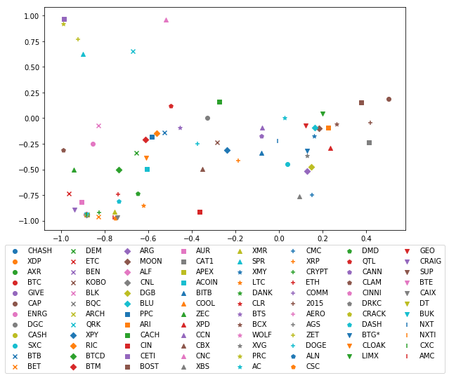

```python
# Plotting embedded series
fig, ax = plt.subplots(1, 1, figsize=(8, 5))
for (coin, serie), marker in zip(series_norm.items(), ''.join([x * 10 for x in 'oxDs^*+pv|'])):
    encoded_serie = encoder.predict(serie.reshape(1, -1))
    ax.scatter(encoded_serie[0, 0], encoded_serie[0, 1], marker=marker, label=coin)
plt.legend(loc='upper center', bbox_to_anchor=(0.5, -0.05), fancybox=True, shadow=False, ncol=8)
plt.tight_layout()
plt.show()
```

Una manera de entender lo aprendido por el autoencoder es visualizar series originales de las monedas que se encuentran cercanas en la representación compacta. Visualizando las series cercanas es posible hacerse una idea de lo que representa ese punto del espacio gracias a las características comunes de ese grupo de series.

Por otro lado, explorar distintos grupos a lo largo del espacio permite comprender mejor la implicación de las dimensiones aprendidas.

**Implementación y análisis:** Seleccionar 3 grupos de puntos distintos a lo largo del espacio y visualizar sus series. Analizar los grupos y sus diferencias para tratar de dar una interpretación a cada una de las dimensiones.

**Solución:**  
- El primer grupo de series seleccionadas tiene una clara tendencia ascendente.  
- El segundo tiene un ascenso a mitad de la serie y un descenso al final de la misma.  
- El tercer grupo tiene una tendencia ascendente como el primero. Pero a diferencia de este, las series tienen más actividad en sus primeros valores (no son tan planas).  
- El cuarto grupo se compone de series bastante planas con valores bajos que tienen en común un pico. Aunque dada la función de coste, el requisito para estar dentro del grupo no sea tanto el pico sino como su gran cantidad de valores bajos.  
Aparentemente la primera dimensión (eje *x*) representa mayoría de valores bajos en la serie a su izquierda y mayoría de valores altos a su derecha. La segunda dimensión (eje *y*) parece representar series ascendentes cuando tiene valores bajos y tendencias descendentes a valores altos.

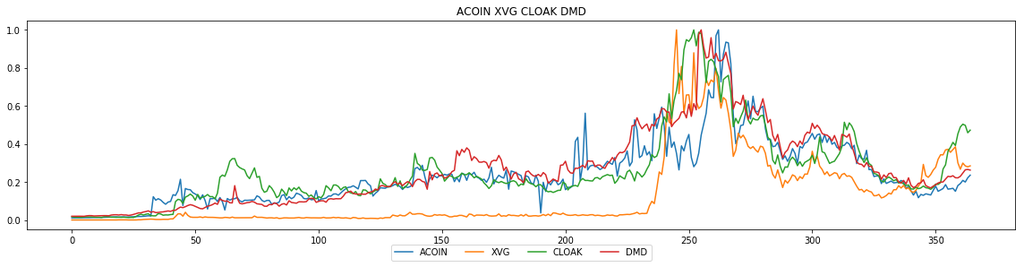

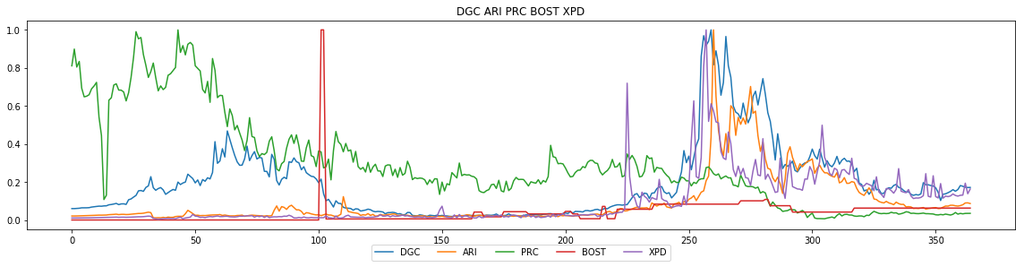

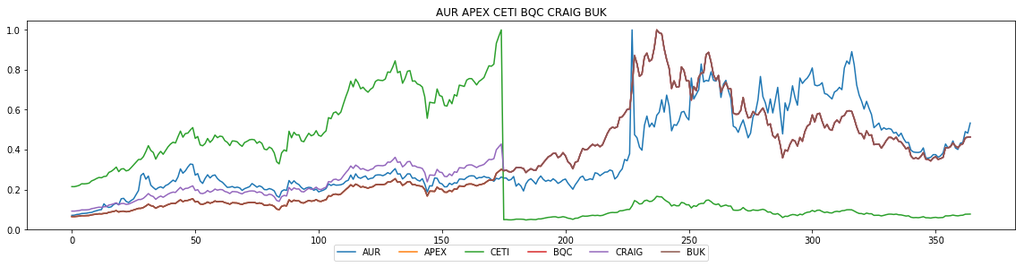

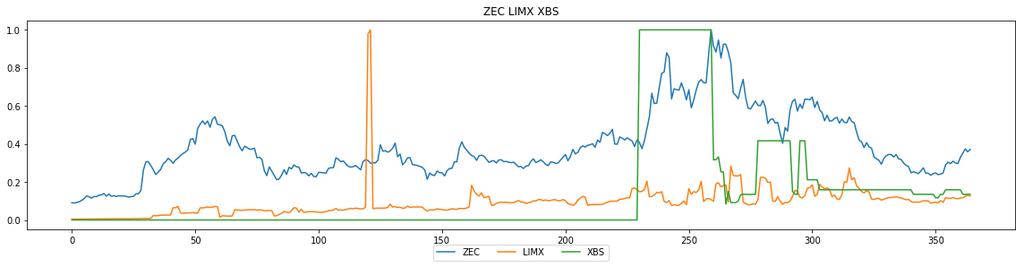

```python
# Plotting selected groups (manual clusters) from the scatter above to infer the role of each dimension
groups = [['ACOIN', 'XVG', 'CLOAK', 'DMD'],
          ['DGC', 'ARI', 'PRC', 'BOST', 'XPD'],
          ['AUR', 'APEX', 'CETI', 'BQC', 'CRAIG', 'BUK'],
          ['ZEC', 'LIMX', 'XBS']]
for group in groups:
    fig, ax = plt.subplots(1, 1, figsize=(16, 4))
    for coin in group:
        ax.plot(range(len(series_norm[coin])), series_norm[coin], label=coin)
    ax.set_title(' '.join(group))
    plt.legend(loc='upper center', bbox_to_anchor=(0.5, -0.05), fancybox=True, shadow=False, ncol=8)
    plt.tight_layout()
```